# CS 422 Section 04 Homework 3

Thomas Ehling A20432671

## 2 Practiclum Problems

```r
library(rpart)
library(rpart.plot)
library(cluster)
library(factoextra)
library(ggplot2)
library(fpc)
```

## 2.1 Problem 1

```r
set.seed(1122)
#setwd('/home/french_magician/Documents/Chicago/DM/Assigment_3')
rm(list=ls())
options("digits"=3)
df_mammals <- read.csv("mammals.csv", sep=",", header=T)
head(df_mammals)
```

|  | Name | I | i | C | c | P | p | M | m |
| --- | --- | --- | --- | --- | --- | --- | --- | --- | --- |
| 1 | Opossum | 5 | 4 | 1 | 1 | 3 | 3 | 4 | 4 |
| 2 | Hairy_tail_mole | 3 | 3 | 1 | 1 | 4 | 4 | 3 | 3 |
| 3 | Common_mole | 3 | 2 | 1 | 0 | 3 | 3 | 3 | 3 |
| 4 | Star_nose_mole | 3 | 3 | 1 | 1 | 4 | 4 | 3 | 3 |
| 5 | Brown_bat | 2 | 3 | 1 | 1 | 3 | 3 | 3 | 3 |
| 6 | Silver_hair_bat | 2 | 3 | 1 | 1 | 2 | 3 | 3 | 3 |

```r
summary(df_mammals)
```

```
        Name          I             i              C               c               P              p              M              m
 Antelope : 1   Min.   :0.0   Min.   :0.00   Min.   :0.000   Min.   :0.000   Min.   :0.00   Min.   :0.00   Min.   :0.00   Min.   :0.00
 Armadillo: 1   1st Qu.:1.0   1st Qu.:1.00   1st Qu.:0.000   1st Qu.:0.000   1st Qu.:2.00   1st Qu.:1.00   1st Qu.:1.00   1st Qu.:2.00
 Badger   : 1   Median :2.0   Median :3.00   Median :1.000   Median :1.000   Median :3.00   Median :3.00   Median :3.00   Median :3.00
 Bear     : 1   Mean   :1.8   Mean   :2.38   Mean   :0.591   Mean   :0.545   Mean   :2.56   Mean   :2.42   Mean   :2.45   Mean   :2.64
 Beaver   : 1   3rd Qu.:3.0   3rd Qu.:3.00   3rd Qu.:1.000   3rd Qu.:1.000   3rd Qu.:3.00   3rd Qu.:3.00   3rd Qu.:3.00   3rd Qu.:3.00
 Bison    : 1   Max.   :5.0   Max.   :4.00   Max.   :1.000   Max.   :1.000   Max.   :4.00   Max.   :4.00   Max.   :8.00   Max.   :8.00
 (Other)  :60
```

```r
str(df_mammals$Name)
```

```
 Factor w/ 66 levels "Antelope","Armadillo",..: 45 28 11 62 8 59 48 30 54 29 ...
```

```r
#df_mammals$Name <- as.factor(df_mammals$Name)
#str(df_mammals$Name)
```

### 2.1-A.i

```r
df_mammals[2:9] <- scale(df_mammals[2:9])
```

```r
# d <- dist(df_mammals[2:9], method="euclidean", upper=T, diag=T) # L2
# d
# d <- dist(df_mammals[2:9], method="manhattan", upper=T, diag=T) # L1
# d
# d <- dist(df_mammals[2:9], method="maximum", upper=T, diag=T) # L_max
#d
```

Sould we remove C and c ? I think we should not remove any of these logically.

### 2.1-A.iii

Done

### 2.1-B.i

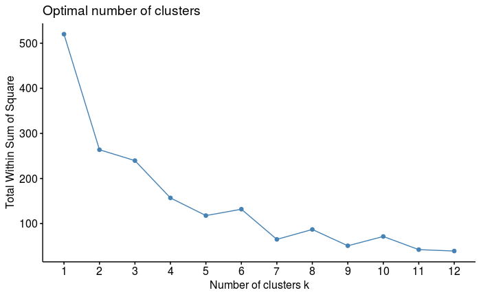

```r
# How many clusters?  A couple of means to visuzalize it.
fviz_nbclust(df_mammals[2:9], kmeans, method="wss", k.max = 12) # Elbow method minimizes total
```

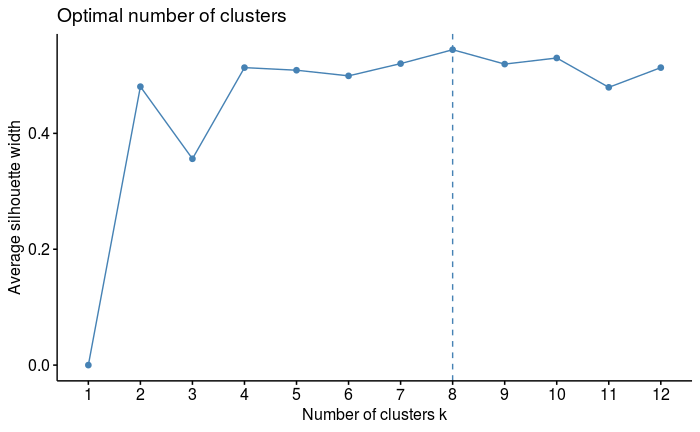

````r
# within-cluster sum of squares (wss).  Also called a "Scree" plot.
# Silhouette measures the quality of a cluster, i.e., how well each
# point lies within its cluster.
fviz_nbclust(df_mammals[2:9], kmeans, method="silhouette", k.max = 12) # But hey, what does it know?```
````

### 2.1-B-ii

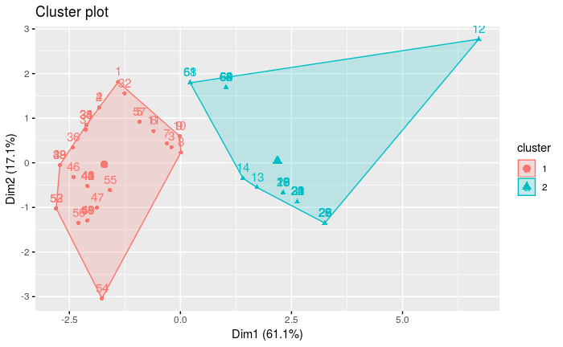

```r
# What happens if we choose more clusters?
fviz_cluster(kmeans(df_mammals[2:9], centers=2, nstart=25), data=df_mammals[2:9])
```

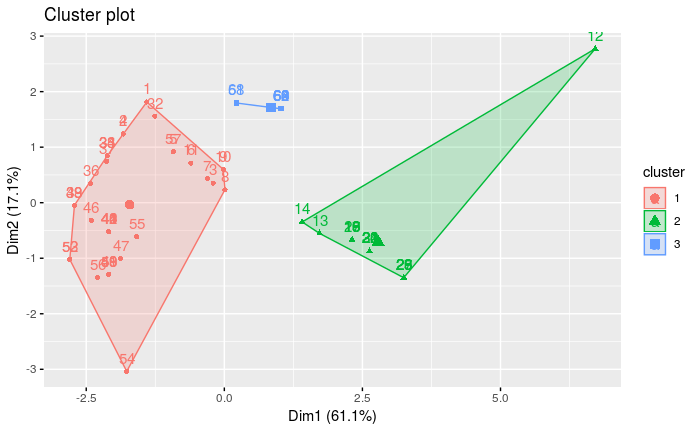

```r
# Is 4 enough?  Or 5?  Or 6?...
fviz_cluster(kmeans(df_mammals[2:9], centers=3, nstart=25), data=df_mammals[2:9])
```

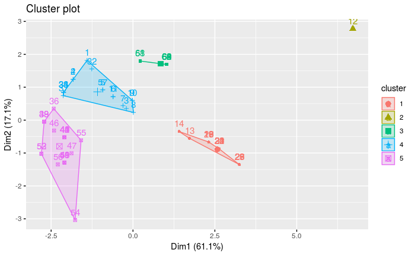

```r
fviz_cluster(kmeans(df_mammals[2:9], centers=5, nstart=25), data=df_mammals[2:9])
```

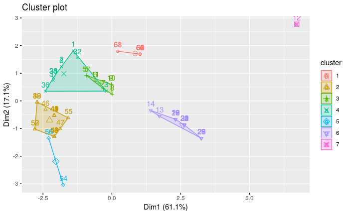

```r
fviz_cluster(kmeans(df_mammals[2:9], centers=7, nstart=25), data=df_mammals[2:9])
```

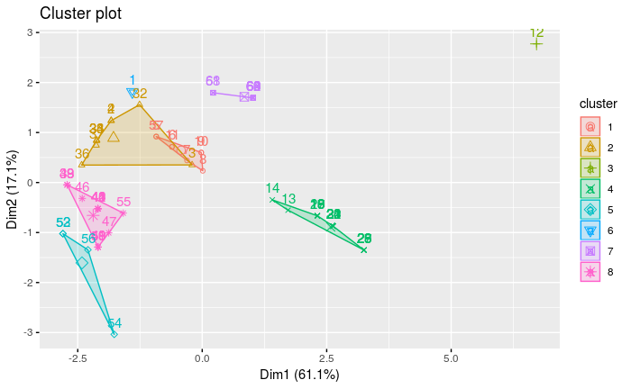

```r
fviz_cluster(kmeans(df_mammals[2:9], centers=8, nstart=25), data=df_mammals[2:9])
```

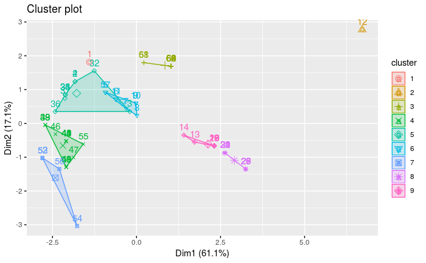

```r
fviz_cluster(kmeans(df_mammals[2:9], centers=9, nstart=25), data=df_mammals[2:9])
```

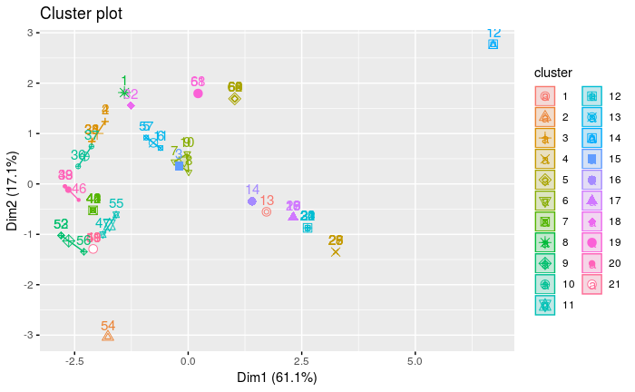

```r
fviz_cluster(kmeans(df_mammals[2:9], centers=21, nstart=25), data=df_mammals[2:9])
```

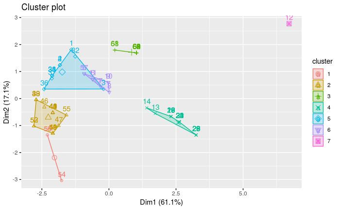

```r
clusters <- kmeans(df_mammals[2:9], centers=7, nstart=150)
fviz_cluster(clusters, data=df_mammals[2:9])
```

I increase the nstart parameter so the composition of the cluster remain constant.

### 2.1-B-iii

```r
str(clusters)
```

```
List of 9
 $ cluster     : int [1:66] 5 5 5 5 6 6 6 6 6 6 ...
 $ centers     : num [1:7, 1:8] -0.254 1.004 -1.512 -0.585 1.004 ...
  ..- attr(*, "dimnames")=List of 2
  .. ..$ : chr [1:7] "1" "2" "3" "4" ...
  .. ..$ : chr [1:8] "I" "i" "C" "c" ...
 $ totss       : num 520
 $ withinss    : num [1:7] 2.22 14.92 6.34 15.57 18.58 ...
 $ tot.withinss: num 61.9
 $ betweenss   : num 458
 $ size        : int [1:7] 2 17 9 19 10 8 1
 $ iter        : int 2
 $ ifault      : int 0
 - attr(*, "class")= chr "kmeans"
```

```r
df_mammals$Cluster_nb <- as.factor(clusters$cluster)
summary(df_mammals)
```

```
        Name          I                i                C                c                P                p                M               m         Cluster_nb
 Antelope : 1   Min.   :-1.512   Min.   :-2.050   Min.   :-1.193   Min.   :-1.087   Min.   :-2.104   Min.   :-1.915   Min.   :-2.11   Min.   :-2.59   1: 2
 Armadillo: 1   1st Qu.:-0.673   1st Qu.:-1.188   1st Qu.:-1.193   1st Qu.:-1.087   1st Qu.:-0.461   1st Qu.:-1.125   1st Qu.:-1.25   1st Qu.:-0.63   2:17
 Badger   : 1   Median : 0.165   Median : 0.535   Median : 0.826   Median : 0.906   Median : 0.361   Median : 0.455   Median : 0.47   Median : 0.36   3: 9
 Bear     : 1   Mean   : 0.000   Mean   : 0.000   Mean   : 0.000   Mean   : 0.000   Mean   : 0.000   Mean   : 0.000   Mean   : 0.00   Mean   : 0.00   4:19
 Beaver   : 1   3rd Qu.: 1.004   3rd Qu.: 0.535   3rd Qu.: 0.826   3rd Qu.: 0.906   3rd Qu.: 0.361   3rd Qu.: 0.455   3rd Qu.: 0.47   3rd Qu.: 0.36   5:10
 Bison    : 1   Max.   : 2.681   Max.   : 1.397   Max.   : 0.826   Max.   : 0.906   Max.   : 1.183   Max.   : 1.245   Max.   : 4.76   Max.   : 5.27   6: 8
 (Other)  :60                                                                                                                                         7: 1
```

```r
cluster_sizes <- clusters$size
for( size in  1:length(cluster_sizes) ){
  cat(paste("The Cluster ",size," have ", cluster_sizes[size], " observations"))
  cat(paste("\n\n"))
}
```

```
The Cluster  1  have  2  observations

The Cluster  2  have  17  observations

The Cluster  3  have  9  observations

The Cluster  4  have  19  observations

The Cluster  5  have  10  observations

The Cluster  6  have  8  observations

The Cluster  7  have  1  observations
```

### 2.1-B-iv

```r
cat(paste("The sse is ", clusters$tot.withinss))
```

```
The sse is  61.8750144556537
```

### 2.1-B-v

The clusters sse are :

```r
clusters_sse <- clusters$withinss
for( sse in  1:length(clusters_sse) ){
  cat(paste("Cluster",sse," : ", clusters_sse[sse]))
  cat(paste("\n\n"))
}
```

```
Cluster 1  :  2.22356012014552

Cluster 2  :  14.9183731028772

Cluster 3  :  6.33744855967078

Cluster 4  :  15.5681860119391

Cluster 5  :  18.5827510825803

Cluster 6  :  4.24469557844084

Cluster 7  :  0
```

### 2.1-B-vi

```r
for( val_1 in  1:length(cluster_sizes) ){
  cat(paste("Cluster",val_1," : "))
  for (val in which(df_mammals$Cluster_nb == val_1)){ cat(paste(df_mammals$Name[val]," ")) }
  cat(paste("\n\n"))
}
```

```
Cluster 1  : Walrus  Elephant_seal

Cluster 2  : Marten  Fisher  Weasel  Mink  Ferrer  Wolverine  Badger  Skunk  River_otter  Sea_otter  Jaguar  Ocelot  Cougar  Lynx  Fur_seal  Sea_lion  Grey_seal

Cluster 3  : Elk  Deer  Moose  Reindeer  Antelope  Bison  Mountain_goat  Musk_ox  Mountain_sheep

Cluster 4  : Pika  Snowshoe_rabbit  Beaver  Marmot  Groundhog  Prairie_Dog  Ground_Squirrel  Chipmunk  Gray_squirrel  Fox_squirrel  Pocket_gopher  Kangaroo_rat  Pack_rat  Field_mouse  Muskrat  Black_rat  House_mouse  Porcupine  Guinea_pig

Cluster 5  : Opossum  Hairy_tail_mole  Common_mole  Star_nose_mole  Coyote  Wolf  Fox  Bear  Civet_cat  Raccoon

Cluster 6  : Brown_bat  Silver_hair_bat  Pigmy_bat  House_bat  Red_bat  Hoary_bat  Lump_nose_bat  Peccary

Cluster 7  : Armadillo
```

Analysis : There is a large probability that an animals teeth are related to it nutrition, but as we are no expert in this area, our analysis will be on the animal’s types.

Cluster 1 : Coherent : Two huge animals, eating fish and leaving in the sea.

Cluster 2 : Semi-Coherent : If most of the animals in this cluster are living near the water (river or sea), some animals like the jaguar or lynx does not seems to fit with the others.

Cluster 3 : Coherent : regroup animals living in the mountains.

Cluster 4 : Semi-Coherent : Regroup no predators, Only animals we could fine in fields. Include all of the rodents. However some animals like the beaver doesn’t make sense without further analysis.

Cluster 5 : Coherent, composed of animals living in arid area : moles, coyotes, wolfs,foxes. And all these animals are carnivors.

Cluster 6 : Coherent : gather all the bats of the sata set. However the Peccary look like an mistake

Cluster 7 : Composed of only one special animal, the Armadillo, wich seems to have a dentition on his own.

That is really good, because no cluster is extremely incoherent.

## 2.2 Problem 2

```r
set.seed(1122)
df_mammals <- read.csv("mammals.csv", sep=",", header=T, row.names = 1)
df_mammals_sample <- dplyr::sample_n(df_mammals, 35)
df_mammals_sample
```

|  | I | i | C | c | P | p | M | m |
| --- | --- | --- | --- | --- | --- | --- | --- | --- |
| Silver_hair_bat | 2 | 3 | 1 | 1 | 2 | 3 | 3 | 3 |
| Opossum | 5 | 4 | 1 | 1 | 3 | 3 | 4 | 4 |
| Badger | 3 | 3 | 1 | 1 | 3 | 3 | 1 | 2 |
| Hoary_bat | 1 | 3 | 1 | 1 | 2 | 2 | 3 | 3 |
| Porcupine | 1 | 1 | 0 | 0 | 1 | 1 | 3 | 3 |
| House_mouse | 1 | 1 | 0 | 0 | 0 | 0 | 3 | 3 |
| Deer | 0 | 4 | 0 | 0 | 3 | 3 | 3 | 3 |
| Lump_nose_bat | 2 | 3 | 1 | 1 | 2 | 3 | 3 | 3 |
| Groundhog | 1 | 1 | 0 | 0 | 2 | 1 | 3 | 3 |
| Musk_ox | 0 | 4 | 0 | 0 | 3 | 3 | 3 | 3 |

[output cut: 25 more lines]

### 2.2-A

```r
link_simple <-  eclust(df_mammals_sample, "hclust", graph = TRUE, hc_method = "single")
```

```
Clustering k = 1,2,..., K.max (= 10): .. done
Bootstrapping, b = 1,2,..., B (= 100)  [one "." per sample]:
.................................................. 50
.................................................. 100
```

```r
link_complete <-  eclust(df_mammals_sample, "hclust", graph = TRUE, hc_method = "complete")
```

```
Clustering k = 1,2,..., K.max (= 10): .. done
Bootstrapping, b = 1,2,..., B (= 100)  [one "." per sample]:
.................................................. 50
.................................................. 100
```

```r
link_average <-  eclust(df_mammals_sample, "hclust", graph = TRUE, hc_method = "average")
```

```
Clustering k = 1,2,..., K.max (= 10): .. done
Bootstrapping, b = 1,2,..., B (= 100)  [one "." per sample]:
.................................................. 50
.................................................. 100
```

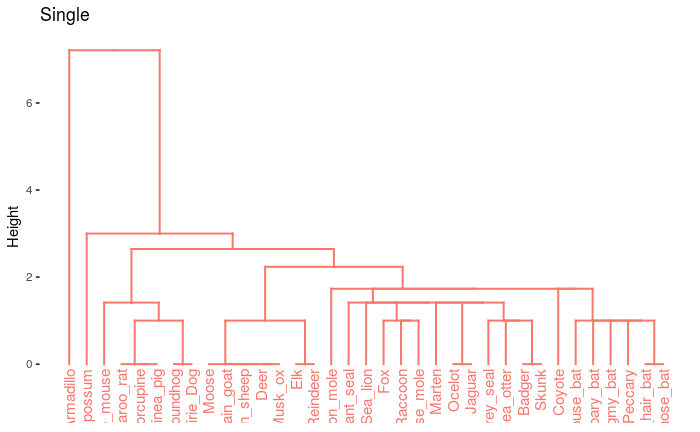

```r
fviz_dend(link_simple, main = "Single", show_labels = TRUE, color_labels_by_k = TRUE)
```

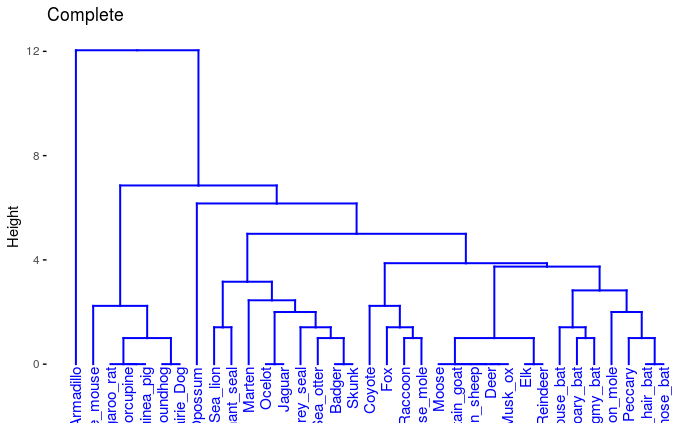

```r
fviz_dend(link_complete , main = "Complete",  k_colors = c("blue"))
```

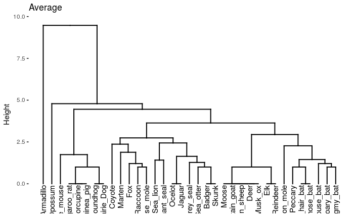

```r
fviz_dend(link_average, main = "Average",  k_colors = c("black"))
```

### 2.2-B

The two-singletons clusters :

Compexe : 8 {Groundhog, Prairie_Dog} {Sea_Lion, Elephant_seal} {Ocelot , Jaguar} {Badger, Skunk} {Raccoon, Star_nose_mole} {Elk, Reindeer} {Hoary_bat, Pigmy_bat} {Silver_hair_bat, Lump_nose_bat}

### 2.2-C

It would be the simple linkage, because it has less two-singleton clusters than the others.

### 2.2-D

Depends on the chosen one.

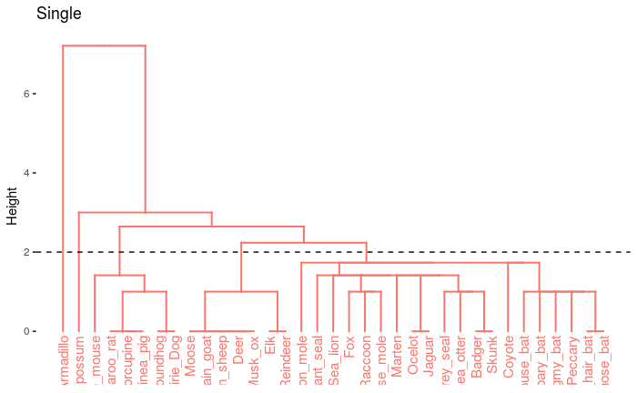

```r
fviz_dend(link_simple, main = "Single", show_labels = TRUE, color_labels_by_k = TRUE) + geom_hline(yintercept = 2, linetype = 2)
```

For a height of 2, we would have 5 clusters.

### 2.2-E

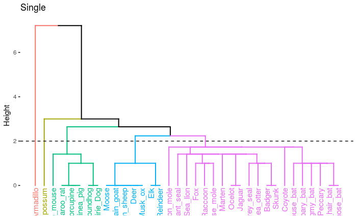

```r
link_simple <-  eclust(df_mammals_sample, "hclust",  k = 5, graph = TRUE, hc_method = "single")
link_complete <-  eclust(df_mammals_sample, "hclust",  k = 5, graph = TRUE, hc_method = "complete")
link_average <-  eclust(df_mammals_sample, "hclust", k = 5, graph = TRUE, hc_method = "average")
fviz_dend(link_simple, main = "Single", show_labels = TRUE, color_labels_by_k = TRUE) + geom_hline(yintercept = 2, linetype = 2)
```

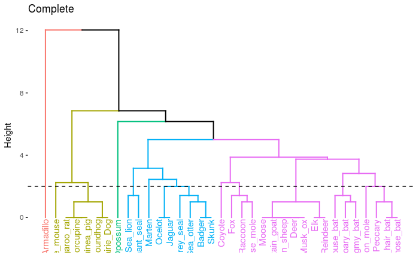

```r
fviz_dend(link_complete , main = "Complete",  color_labels_by_k = TRUE) + geom_hline(yintercept = 2, linetype = 2)
```

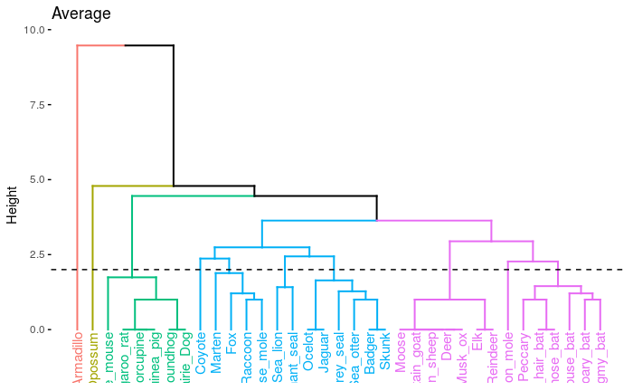

```r
fviz_dend(link_average, main = "Average",  color_labels_by_k = TRUE) + geom_hline(yintercept = 2, linetype = 2)
```

### 2.2-F

```r
options("digits"=3)
dd <- dist(df_mammals_sample, method ="euclidean")
stat_single <- cluster.stats(d = dd, link_simple$cluster, silhouette = TRUE)
stat_complete <- cluster.stats(d = dd, link_complete$cluster, silhouette = TRUE)
stat_average <- cluster.stats(d = dd, link_average$cluster, silhouette = TRUE)
cat(paste("\n linkage simgle :  dun : ", stat_single$dunn, " and silhouette : ", stat_single$avg.silwidth))
```

```
 linkage simgle :  dun :  0.447213595499958  and silhouette :  0.444620403270988
```

```r
cat(paste("\n linkage complete :  dun : ", stat_complete$dunn, " and silhouette : ", stat_complete$avg.silwidth))
```

```
 linkage complete :  dun :  0.365148371670111  and silhouette :  0.398595758939725
```

```r
cat(paste("\n linkage average :  dun : ", stat_average$dunn, " and silhouette : ", stat_average$avg.silwidth))
```

```
 linkage average :  dun :  0.420084025208403  and silhouette :  0.413362521469499
```

### 2.2-G

The single linkage model has the highest dunn and silhouette width, so we would choose it. That correlate with the informations found before.

## 2.3 Problem 2

### 2.3

```r
set.seed(1122)
setwd('/home/french_magician/Documents/Chicago/DM/Assigment_3')
```

```
The working directory was changed to /home/french_magician/Documents/Chicago/DM/Assigment_3 inside a notebook chunk. The working directory will be reset when the chunk is finished running. Use the knitr root.dir option in the setup chunk to change the working directory for notebook chunks.
```

```r
rm(list=ls())
options("digits"=3)
df_htru <- read.csv("HTRU_2-small.csv", sep=",", header=T)
head(df_htru)
```

|  | mean | std.dev | kurtosis | skewness | mean.dm.snr | std.dev.dm.snr | kurtosis.dm.snr | skewness.dm.snr | class |
| --- | --- | --- | --- | --- | --- | --- | --- | --- | --- |
| 1 | 46 | 39 | 3.6469 | 13.77 | 127.9 | 73 | 0.068 | -0.83 | 1 |
| 2 | 122 | 45 | 0.2318 | 0.18 | 3.8 | 23 | 6.719 | 47.95 | 0 |
| 3 | 113 | 49 | 0.2729 | 0.27 | 94.9 | 84 | -0.212 | -1.86 | 0 |
| 4 | 130 | 51 | -0.1601 | -0.21 | 2.0 | 13 | 10.016 | 138.33 | 0 |
| 5 | 111 | 36 | 0.2377 | 1.68 | 3.7 | 19 | 6.663 | 54.09 | 0 |
| 6 | 138 | 53 | -0.0091 | -0.55 | 2.2 | 13 | 9.954 | 139.47 | 0 |

```r
df_htru_scaled <- scale(df_htru)
pca <- prcomp(df_htru_scaled)
names(pca)
```

```
[1] "sdev"     "rotation" "center"   "scale"    "x"
```

```r
pca$sdev
```

```
[1] 2.180 1.475 0.903 0.707 0.564 0.511 0.383 0.132 0.124
```

### 2.3-A.i

```r
options("digits"=2)
variances <- pca$sdev
cat(paste("Total TCumulative variance :", sum(variances)))
```

```
Total TCumulative variance : 6.97771834874486
```

```r
cat(paste("\nThe first component explains ", variances[1]/sum(variances)*100," %"))
```

[output not shown]

```r
cat(paste("\nThe second component explains ", variances[2]/sum(variances)*100," %"))
```

[output not shown]

### 2.3-A.ii

```r
pca$rotation <- -pca$rotation
pca$rotation
```

```
                  PC1   PC2    PC3    PC4   PC5      PC6    PC7    PC8    PC9
mean            -0.35  0.31 0.0075  0.130 -0.36  0.73762 -0.055  0.289  0.023
std.dev         -0.21  0.40 0.4756 -0.691  0.29  0.01943  0.070 -0.056 -0.011
kurtosis         0.41 -0.27 0.0732 -0.180  0.24  0.15047  0.066  0.795  0.075
skewness         0.38 -0.26 0.0531 -0.041  0.29  0.65114  0.069 -0.513 -0.058
mean.dm.snr      0.30  0.29 0.5420  0.433  0.11 -0.05520 -0.567  0.026 -0.090
std.dev.dm.snr   0.35  0.35 0.2138  0.231 -0.21 -0.06597  0.746  0.011 -0.233
kurtosis.dm.snr -0.32 -0.44 0.2812  0.027 -0.04 -0.00082  0.012  0.079 -0.782
skewness.dm.snr -0.25 -0.42 0.5742  0.191 -0.13 -0.02057  0.232 -0.056  0.562
class            0.37 -0.14 0.1315 -0.440 -0.76 -0.03296 -0.225 -0.094 -0.014
```

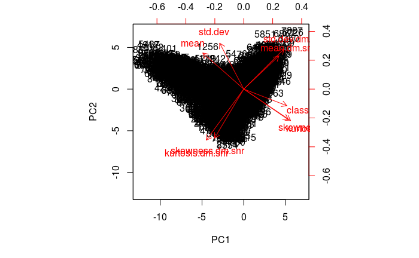

```r
biplot(pca, scale=0)
```

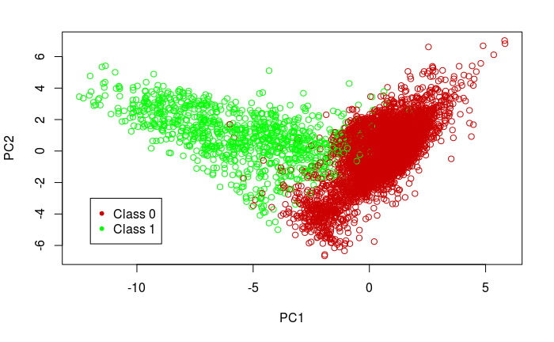

```r
df_htru$class = as.factor(df_htru$class)
classcolor = c("#CC0000", "green")[df_htru$class]
plot(pca$x[,1],pca$x[,2], col =  classcolor, xlab = "PC1", ylab="PC2")
legend(-12, -3, legend=c("Class 0", "Class 1"), col=c("#CC0000", "green"), pch=c(20,20))
```

### 2.3-A.iii

We know that PC1 is representative of the attributes : mean, kurtosis, skewness, mean.dm.snr ans class

And PC2 : std.dev, kurtosis.dm.snr, skewness.dm.snr.

For the class O : - The elements of the clas 0 are equally spread along the y axis, so the attributes represented by PC2 does not have any effects on the distribution. - However, on the x absis, they remain ammong the positive values, and so, coerce with the attributes that represent PC1.

### 2.3-B

### 2.3-B-i

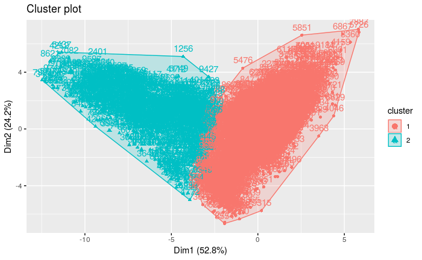

```r
clusters <- kmeans(df_htru_scaled, centers=2, nstart=25)
fviz_cluster(clusters, df_htru_scaled)
```

### 2.3-B.ii

The two clusters are similar to the two class found in a(ii).

This is normal because the two principal component from PCA represents roughly the same variance as the original distribution.

### 2.3-B.iii

```r
cluster_sizes <- clusters$size
for( size in  1:2 ){
  cat(paste("The Cluster ",size," have ", cluster_sizes[size], " observations"))
  cat(paste("\n\n"))
}
```

```
The Cluster  1  have  9183  observations

The Cluster  2  have  817  observations
```

### 2.3-B.iv

```r
cat(paste("The Class 0 have ", sum(df_htru[,9] == "0"), " observations"))
```

```
The Class 0 have  9041  observations
```

```r
cat(paste("\n\n"))
```

```r
cat(paste("The Class 1 have ", sum(df_htru[,9] == "1"), " observations"))
```

```
The Class 1 have  959  observations
```

```r
cat(paste("\n\n"))
```

### 2.3-B.v

According to the number of observations, the cluster 1 correspond to the majority class 0, and the cluster 2 correpond to the minority class 1.

### 2.3-B.vi

```r
cat(paste("The Cluster 1 have ", cluster_sizes[1], " observations"))
```

```
The Cluster 1 have  9183  observations
```

```r
cluter1_cl0 <- sum(clusters$cluster == "1" & df_htru[,9] == "0")
cluter1_cl1 <- sum(clusters$cluster == "1" & df_htru[,9] == "1")
cat(paste("\nThere are ", cluter1_cl0, " observations from class 0"))
```

```
There are  9019  observations from class 0
```

```r
cat(paste("\nThere are ", cluter1_cl1, " observations from class 1"))
```

```
There are  164  observations from class 1
```

### 2.3-B.vii

The large cluster, cluster 1, represents the CLass 0. This correlate with the previous observations.

### 2.3-B.viii

```r
variance <- (clusters$betweenss / clusters$totss) * 100
cat(paste(variance, "% of the total variance is explained by clustering. \n"))
```

```
39.1225512803636 % of the total variance is explained by clustering.
```

### 2.3-B.ix

```r
statistic<- cluster.stats(dist(df_htru_scaled, method = "euclidean"), clusters$cluster, silhouette = TRUE)
```

As it takes a long time to compute, I copy paste the results here : “The average silhouette Width is 0.64”

### 2.3-B.x

The average silhouette width for cluster 1 is : 0.66 The average silhouette width for cluster 2 is : 0.37

According to this result, cluster number 1 is better, as it has the highest silhouette width.

### 2.3-C.iii

According to this result, cluster number 1 is better, as it has the highest silhouette width.